# Practical Machine Learning Coursera Assignment

G. Scotti

5/8/2018

# Synopsis

One thing that people regularly do is quantify how much of a particular activity they do, but they rarely quantify how well they do it. In this project, the goal is to use data from accelerometers on the belt, forearm, arm, and dumbell of 6 participants to predict the manner in which they did the exercise (the “classe” variable in the training set). In the following we build a prediction model and compute the expected out of sample error. Then the prediction model is finally used to predict 20 different test cases.

# Online version

The Github pages version of this report can be found at: https://navingio.github.io/PML_Final_Assignment/

# Data Processing

## Loading the data

```r
raw_training = read.csv("pml-training.csv")
dim(raw_training)
```

```
## [1] 19622   160
```

```r
raw_testing = read.csv("pml-testing.csv")
dim(raw_testing)
```

```
## [1]  20 160
```

## Preprocessing

create a suitable training data set, by cleaning up the raw_training data :  
1) leaving only predictors that have less than 10% NA values  
2) leaving predictors that have no more than 90% empty values  
3) removing predictors that are not useful (‘X’ and timestamp values)

```r
# 1
raw_training <- raw_training[, colSums(is.na(raw_training)) < nrow(raw_training) * 0.1]
dim(raw_training)
```

```
## [1] 19622    93
```

```r
# 2
raw_training <- raw_training[, colSums(raw_training == "") < nrow(raw_training) * 0.9]
dim(raw_training)
```

```
## [1] 19622    60
```

```r
# 3
good_training <- raw_training[ , -which(names(raw_training) %in% c("X","raw_timestamp_part_1", "raw_timestamp_part_2", "cvtd_timestamp"))]
dim(good_training)
```

```
## [1] 19622    56
```

```r
names(good_training)
```

```
##  [1] "user_name"            "new_window"           "num_window"
##  [4] "roll_belt"            "pitch_belt"           "yaw_belt"
##  [7] "total_accel_belt"     "gyros_belt_x"         "gyros_belt_y"
## [10] "gyros_belt_z"         "accel_belt_x"         "accel_belt_y"
## [13] "accel_belt_z"         "magnet_belt_x"        "magnet_belt_y"
## [16] "magnet_belt_z"        "roll_arm"             "pitch_arm"
## [19] "yaw_arm"              "total_accel_arm"      "gyros_arm_x"
## [22] "gyros_arm_y"          "gyros_arm_z"          "accel_arm_x"
## [25] "accel_arm_y"          "accel_arm_z"          "magnet_arm_x"
## [28] "magnet_arm_y"         "magnet_arm_z"         "roll_dumbbell"
## [31] "pitch_dumbbell"       "yaw_dumbbell"         "total_accel_dumbbell"
## [34] "gyros_dumbbell_x"     "gyros_dumbbell_y"     "gyros_dumbbell_z"
## [37] "accel_dumbbell_x"     "accel_dumbbell_y"     "accel_dumbbell_z"
## [40] "magnet_dumbbell_x"    "magnet_dumbbell_y"    "magnet_dumbbell_z"
## [43] "roll_forearm"         "pitch_forearm"        "yaw_forearm"
## [46] "total_accel_forearm"  "gyros_forearm_x"      "gyros_forearm_y"
## [49] "gyros_forearm_z"      "accel_forearm_x"      "accel_forearm_y"
## [52] "accel_forearm_z"      "magnet_forearm_x"     "magnet_forearm_y"
## [55] "magnet_forearm_z"     "classe"
```

Build ‘training’ and ‘validation’ sets from ‘good_training’. ‘validation’ will be used later for Cross Validation (see below). Training and Validation data set have sizes: 70% and 30% of the original good_training respectively.

```r
library(caret,quietly=TRUE)
trainingIndexes <- createDataPartition(y = good_training$classe, p = 0.7, list = FALSE)
training <- good_training[trainingIndexes, ]
dim(training)
```

```
## [1] 13737    56
```

```r
validating <- good_training[-trainingIndexes, ]
dim(validating)
```

```
## [1] 5885   56
```

create the ‘testing’ data frame from raw_testing, by leaving the same columns that are present in the training data set.

```r
testing <- raw_testing[ , which(names(raw_testing) %in% as.vector(names(training)) )]
ncol(testing)
```

```
## [1] 55
```

notice: testing does not include the column ‘classe’, as not provided in the original pml-testing.csv file, in fact the quiz requires to predict the values of classe.

## Processing

In the following we will use the Random Forest classification method with the caret::train() function; in order to speed up the model training process we will tell R to make use of parallel processing and we will configure the trainControl object for cross validation (see https://github.com/lgreski/datasciencectacontent/blob/master/markdown/pml-randomForestPerformance.md).

### Configure parallel processing

```r
library(parallel,quietly=TRUE)
library(doParallel,quietly=TRUE)
cluster <- makeCluster(detectCores() - 1)
registerDoParallel(cluster)
cluster
```

```
## socket cluster with 3 nodes on host 'localhost'
```

### Cross Validation

By default train() uses a bootstrap re-sampling process which is very time consuming. In the following we replace it with a 3-fold cross-validation which has no impact on accuracy but significantly speeds up the execution. The trainControl() from caret is used:

```r
library(caret,quietly=TRUE)
fitControl <- trainControl(method = "cv", number = 3, allowParallel = TRUE)
```

### Model Training

Train a Random Forest model using the train control above defined.

```r
modFit  <- train(classe ~ ., method = "rf", data = training, trControl = fitControl)
```

De-register parallel processing cluster

```r
stopCluster(cluster)
registerDoSEQ()
```

Inspect the trained model

```r
modFit
```

```
## Random Forest
##
## 13737 samples
##    55 predictor
##     5 classes: 'A', 'B', 'C', 'D', 'E'
##
## No pre-processing
## Resampling: Cross-Validated (3 fold)
## Summary of sample sizes: 9157, 9159, 9158
## Resampling results across tuning parameters:
##
##   mtry  Accuracy   Kappa
##    2    0.9906095  0.9881204
##   30    0.9953410  0.9941067
##   59    0.9923566  0.9903312
##
## Accuracy was used to select the optimal model using the largest value.
## The final value used for the model was mtry = 30.
```

```r
modFit$finalModel
```

```
##
## Call:
##  randomForest(x = x, y = y, mtry = param$mtry)
##                Type of random forest: classification
##                      Number of trees: 500
## No. of variables tried at each split: 30
##
##         OOB estimate of  error rate: 0.2%
## Confusion matrix:
##      A    B    C    D    E  class.error
## A 3904    1    0    0    1 0.0005120328
## B    6 2647    4    1    0 0.0041384500
## C    0    3 2393    0    0 0.0012520868
## D    0    0    9 2242    1 0.0044404973
## E    0    0    0    1 2524 0.0003960396
```

```r
confusionMatrix.train(modFit)
```

```
## Cross-Validated (3 fold) Confusion Matrix
##
## (entries are percentual average cell counts across resamples)
##
##           Reference
## Prediction    A    B    C    D    E
##          A 28.4  0.1  0.0  0.0  0.0
##          B  0.0 19.2  0.1  0.0  0.0
##          C  0.0  0.0 17.4  0.1  0.0
##          D  0.0  0.0  0.0 16.3  0.1
##          E  0.0  0.0  0.0  0.0 18.3
##
##  Accuracy (average) : 0.9953
```

Most important variables (list and plot) and accuracy by Predictor Count

```r
library(randomForest,quietly=TRUE)
varImp(modFit)
```

```
## rf variable importance
##
##   only 20 most important variables shown (out of 59)
##
##                      Overall
## num_window           100.000
## roll_belt             68.471
## pitch_forearm         40.098
## yaw_belt              33.535
## magnet_dumbbell_z     32.384
## magnet_dumbbell_y     31.110
## pitch_belt            29.242
## roll_forearm          25.382
## accel_dumbbell_y      15.236
## roll_dumbbell         12.217
## accel_forearm_x       11.891
## magnet_dumbbell_x     11.350
## accel_belt_z          10.705
## total_accel_dumbbell   9.805
## accel_dumbbell_z       8.975
## magnet_forearm_z       7.954
## magnet_belt_z          7.741
## magnet_belt_y          7.680
## magnet_belt_x          6.539
## roll_arm               6.097
```

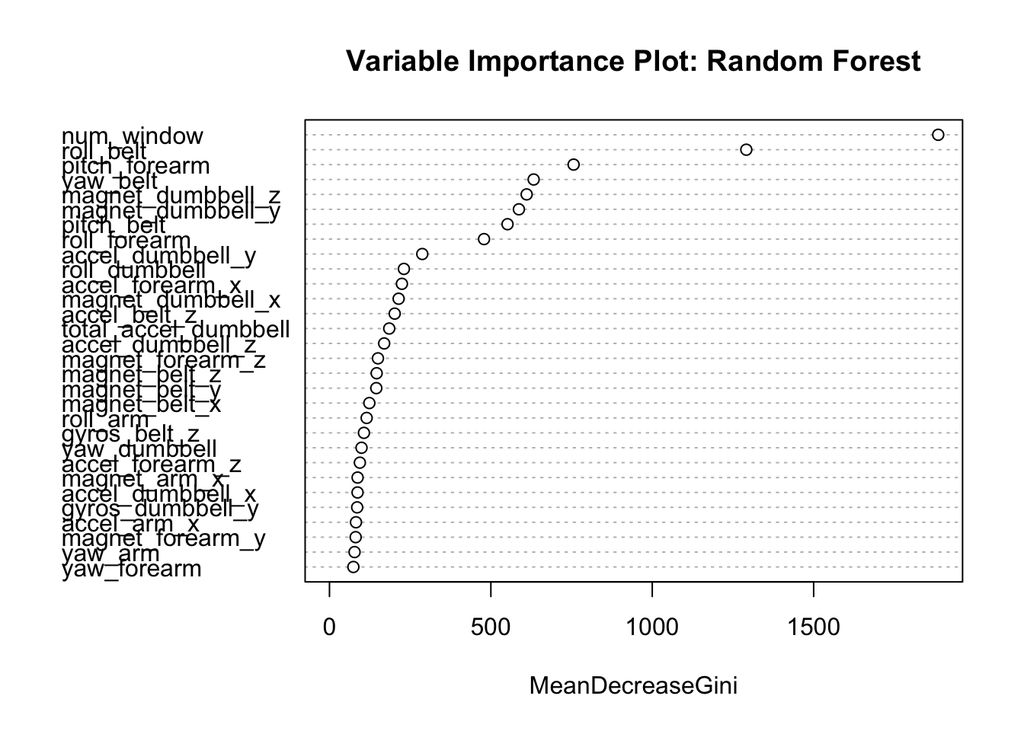

```r
varImpPlot(modFit$finalModel, main="Variable Importance Plot: Random Forest")
```

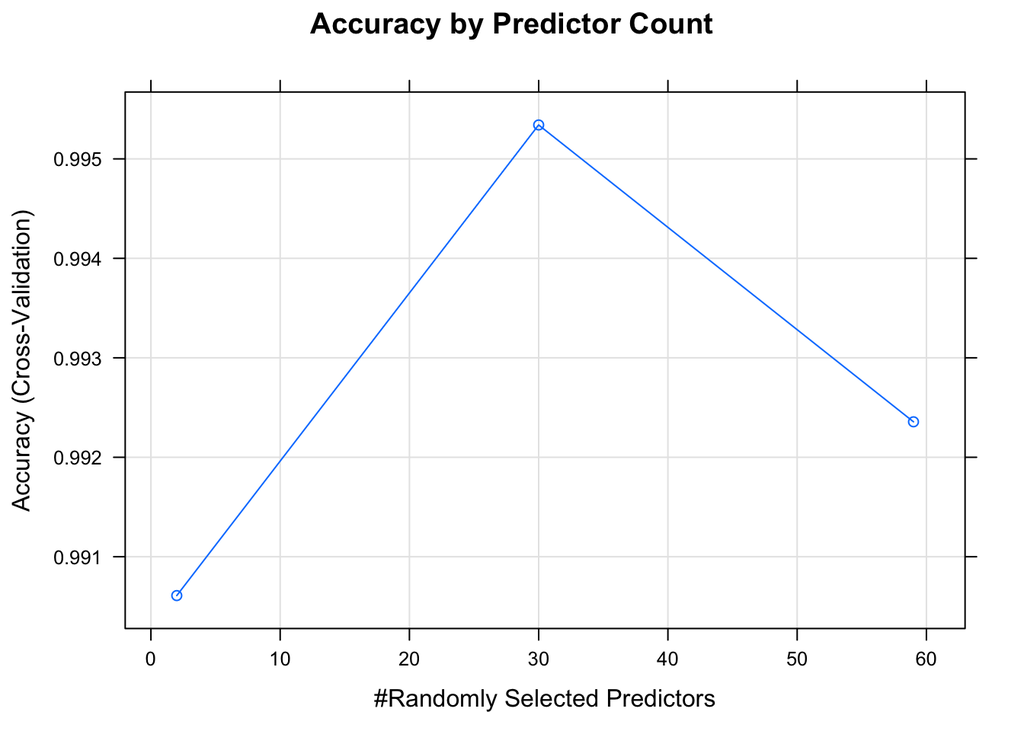

```r
plot(modFit,main="Accuracy by Predictor Count")
```

## Predictions on testing sample

```r
predict(modFit, newdata=testing)
```

```
##  [1] B A B A A E D B A A B C B A E E A B B B
## Levels: A B C D E
```

## Out of sample error

Use the model to predict on the validating data and calculate the accuracy and estimate the out-of-sample error

```r
predOnValidating <- predict(modFit, newdata=validating)

# Number of predictions
length(predOnValidating)
```

```
## [1] 5885
```

```r
#  accuracy of the predicted model
predValAccuracy <- sum(predOnValidating == validating$classe)/length(predOnValidating)
predValAccuracy
```

```
## [1] 0.9964316
```

build the confusion matrix to see the accuracy of the model (alternative measure)

```r
confusionMatrix(predOnValidating, validating$classe)
```

```
## Confusion Matrix and Statistics
##
##           Reference
## Prediction    A    B    C    D    E
##          A 1674    6    0    0    0
##          B    0 1132    3    0    0
##          C    0    1 1022    8    0
##          D    0    0    1  956    2
##          E    0    0    0    0 1080
##
## Overall Statistics
##
##                Accuracy : 0.9964
##                  95% CI : (0.9946, 0.9978)
##     No Information Rate : 0.2845
##     P-Value [Acc > NIR] : < 2.2e-16
##
##                   Kappa : 0.9955
##  Mcnemar's Test P-Value : NA
##
## Statistics by Class:
##
##                      Class: A Class: B Class: C Class: D Class: E
## Sensitivity            1.0000   0.9939   0.9961   0.9917   0.9982
## Specificity            0.9986   0.9994   0.9981   0.9994   1.0000
## Pos Pred Value         0.9964   0.9974   0.9913   0.9969   1.0000
## Neg Pred Value         1.0000   0.9985   0.9992   0.9984   0.9996
## Prevalence             0.2845   0.1935   0.1743   0.1638   0.1839
## Detection Rate         0.2845   0.1924   0.1737   0.1624   0.1835
## Detection Prevalence   0.2855   0.1929   0.1752   0.1630   0.1835
## Balanced Accuracy      0.9993   0.9966   0.9971   0.9955   0.9991
```

Out of sample error estimation

```r
oosError <- 1 - predValAccuracy
oosError
```

```
## [1] 0.003568394
```

```r
oosErrorPercentage <- oosError * 100
oosErrorPercentage
```

```
## [1] 0.3568394
```

The estimated out of sample error is 0.36 %.